# Biodiversity accross a fiber treatment

Roger Calvas

2025-04-30

# Goals

Run an analysis on the within-sample biodiversity of the samples in our project.

1. Calculate the Hill Numbers of the samples using the iNEXT package.
2. Plot and evaluate the interpolated and extrapolated rarefaction curves from iNEXT.
3. Analyze the Hill numbers as it relates to status and short chain fatty acids concenctrations in milimoles per kilogram.
4. Test and then answer the scientific question at hand! (Remember, we’re doing biology!)
1. We will need the `phytree_preprocessed_physeq`, which includes a rooted tree (ideally within the archaea!) that we created in `analysis/04B_Phylogenetic_Tree_Inspection.Rmd`.

## Outputs

*This is an exciting analysis!!! We finally get to answer one of our scientific questions!*

1. Calculated biodiversity measures (Hill numbers) across every sample.
2. Figures to include in our scientific paper that visualize the data as it relates to the scientific question.
3. Statistical tests conveying the measured and quantified changes and patterns in biodiversity.

# Scientific Question

## Question & Hypotheses

How is microbial diversity and short chain fatty acid concentrations (scfa) modified by inulin treatment.

- *Null Hypothesis:* Microbial diversity and scfa production does not vary during inulin treatment
- *Alternative Hypothesis:* Microbial diversity and scfa production will increase during an inulin treatment. Establishing a correlation between fermentable fiber and gut biota.

# Set up the Environment

## Timing of this script

```r
# What time did we start running this script?
start_time <- Sys.time()
```

## Set the seed

```r
set.seed(3980)
```

## Load Packages & Colors

```r
# install packages for stats
#install.packages("rstatix")
#install.packages("ggpubr")

pacman::p_load(tidyverse, devtools, patchwork, iNEXT, phyloseq,
               # packages for stats
               ggpubr, rstatix, install = FALSE)

# Load in colors for plotting
source("code/colors.R")
```

## Load in Data

```r
load("data/04_Phylogenetic_Tree/archaeal_rooted_physeq.RData")

# take a look at it!
archaeal_rooted_physeq
```

```
## phyloseq-class experiment-level object
## otu_table()   OTU Table:         [ 1980 taxa and 161 samples ]
## sample_data() Sample Data:       [ 161 samples by 54 sample variables ]
## tax_table()   Taxonomy Table:    [ 1980 taxa by 9 taxonomic ranks ]
## phy_tree()    Phylogenetic Tree: [ 1980 tips and 1979 internal nodes ]
```

```r
# Intuition check on seq depth
min(sample_sums(archaeal_rooted_physeq))
```

```
## [1] 7215
```

```r
# Make a metadata dataframe
metadata_df <-
  archaeal_rooted_physeq %>%
  sample_data() %>%
  data.frame()

# view of it
glimpse(metadata_df)
```

```
## Rows: 161
## Columns: 54
## $ acetate                        <dbl> 9.254869, 21.097292, 24.269452, 60.4192…
## $ Assay.Type                     <chr> "AMPLICON", "AMPLICON", "AMPLICON", "AM…
## $ AvgSpotLen                     <dbl> 500, 500, 500, 500, 500, 500, 501, 500,…
## $ Bases                          <dbl> 13714630, 18882226, 7215829, 18706078, …
## $ BioProject                     <chr> "PRJNA428736", "PRJNA428736", "PRJNA428…
## $ BioSample                      <chr> "SAMN08298951", "SAMN08299001", "SAMN08…
## $ BioSampleModel                 <chr> "MIMARKS.survey,MIGS/MIMS/MIMARKS.human…
## $ Butyrate                       <dbl> 1.290830, 5.738114, 5.988734, 10.268010…
## $ Bytes                          <dbl> 8506104, 11299306, 4574160, 10979812, 7…
## $ Center.Name                    <chr> "MOTHUR", "MOTHUR", "MOTHUR", "MOTHUR",…
## $ Collection_Date                <chr> "2015-10", "2015-10", "2015-10", "2015-…
## $ Consent                        <chr> "public", "public", "public", "public",…
## $ DATASTORE.filetype             <chr> "fastq,run.zq,sra", "fastq,run.zq,sra",…
```

[output cut: 41 more lines]

## Run iNEXT

```r
# prepare the input data
# Species in rows and the samples in columns
iNEXT_input_df <-
  archaeal_rooted_physeq %>%
  otu_table() %>%
  data.frame()

# Inpect
dim(iNEXT_input_df)
```

```
## [1] 1980  161
```

```r
iNEXT_input_df[1:5, 1:5]
```

```
##          SRR6443836 SRR6443839 SRR6443844 SRR6443871 SRR6443905
## ASV_0914          0          0          0          0          0
## ASV_0997          0          0          0          0          0
## ASV_0758          0          0          0          0          0
## ASV_1606          0          0          0          0          0
## ASV_1768          0          0          0          0          0
```

```r
# Run iNEXT
# Remember to set the seed!
# ASVs in ROWs, samples in COLUMNS
#iNEXT_data <- iNEXT(iNEXT_input_df,
 #                   q = c(0, 1, 2),
 #                   datatype = "abundance")
load("data/05_Biodiversity/iNEXT_data.RData")
# Inspect
str(iNEXT_data)
```

```
## List of 3
##  $ DataInfo:'data.frame':    161 obs. of  14 variables:
##   ..$ Assemblage: chr [1:161] "SRR6443836" "SRR6443839" "SRR6443844" "SRR6443871" ...
##   ..$ n         : num [1:161] 19399 27322 9565 28582 15277 ...
##   ..$ S.obs     : num [1:161] 116 236 124 158 159 161 94 78 103 131 ...
##   ..$ SC        : num [1:161] 1 1 1 1 1 1 1 1 1 1 ...
##   ..$ f1        : num [1:161] 0 0 0 0 0 0 0 0 0 0 ...
##   ..$ f2        : num [1:161] 4 1 2 5 5 6 2 1 7 3 ...
##   ..$ f3        : num [1:161] 3 16 4 5 8 10 3 3 4 12 ...
##   ..$ f4        : num [1:161] 4 3 4 5 3 5 3 5 7 5 ...
##   ..$ f5        : num [1:161] 2 10 3 6 6 6 4 2 2 3 ...
##   ..$ f6        : num [1:161] 3 8 2 5 2 6 1 3 1 0 ...
##   ..$ f7        : num [1:161] 4 5 4 4 5 6 1 4 1 1 ...
##   ..$ f8        : num [1:161] 2 9 4 4 8 1 1 5 3 2 ...
##   ..$ f9        : num [1:161] 1 6 3 4 4 7 4 1 4 3 ...
##   ..$ f10       : num [1:161] 3 4 6 3 4 2 1 1 1 4 ...
##  $ iNextEst:List of 2
##   ..$ size_based    :'data.frame':   19320 obs. of  10 variables:
##   .. ..$ Assemblage: chr [1:19320] "SRR6443836" "SRR6443836" "SRR6443836" "SRR6443836" ...
##   .. ..$ m         : num [1:19320] 1 1078 2156 3233 4311 ...
##   .. ..$ Method    : chr [1:19320] "Rarefaction" "Rarefaction" "Rarefaction" "Rarefaction" ...
##   .. ..$ Order.q   : num [1:19320] 0 0 0 0 0 0 0 0 0 0 ...
##   .. ..$ qD        : num [1:19320] 1 85.4 97.8 103.9 107.5 ...
##   .. ..$ qD.LCL    : num [1:19320] 1 84.2 96.3 102.3 105.8 ...
##   .. ..$ qD.UCL    : num [1:19320] 1 86.7 99.3 105.5 109.2 ...
##   .. ..$ SC        : num [1:19320] 0.0548 0.9819 0.9925 0.9958 0.9973 ...
##   .. ..$ SC.LCL    : num [1:19320] 0.0533 0.9811 0.992 0.9954 0.997 ...
##   .. ..$ SC.UCL    : num [1:19320] 0.0564 0.9826 0.993 0.9962 0.9976 ...
##   ..$ coverage_based:'data.frame':   9177 obs. of  8 variables:
##   .. ..$ Assemblage: chr [1:9177] "SRR6443836" "SRR6443836" "SRR6443836" "SRR6443836" ...
##   .. ..$ SC        : num [1:9177] 0.0548 0.9819 0.9925 0.9958 0.9973 ...
##   .. ..$ m         : num [1:9177] 1 1078 2156 3233 4311 ...
##   .. ..$ Method    : chr [1:9177] "Rarefaction" "Rarefaction" "Rarefaction" "Rarefaction" ...
##   .. ..$ Order.q   : num [1:9177] 0 0 0 0 0 0 0 0 0 0 ...
##   .. ..$ qD        : num [1:9177] 1 85.4 97.8 103.9 107.5 ...
##   .. ..$ qD.LCL    : num [1:9177] 0.981 83.724 95.955 101.912 105.479 ...
##   .. ..$ qD.UCL    : num [1:9177] 1.02 87.12 99.7 105.88 109.58 ...
##  $ AsyEst  :'data.frame':    483 obs. of  7 variables:
##   ..$ Assemblage: chr [1:483] "SRR6443836" "SRR6443836" "SRR6443836" "SRR6443839" ...
##   ..$ Diversity : chr [1:483] "Species richness" "Shannon diversity" "Simpson diversity" "Species richness" ...
##   ..$ Observed  : num [1:483] 116 33.1 18.2 236 83.6 ...
##   ..$ Estimator : num [1:483] 116 33.2 18.2 236 84 ...
##   ..$ s.e.      : num [1:483] 1.987 0.293 0.216 2.033 0.591 ...
##   ..$ LCL       : num [1:483] 116 32.7 17.8 236 82.8 ...
##   ..$ UCL       : num [1:483] 119.9 33.8 18.7 240 85.1 ...
##  - attr(*, "class")= chr "iNEXT"
```

```r
typeof(iNEXT_data)
```

```
## [1] "list"
```

```r
#save(iNEXT_data, file = "data/05_Biodiversity/iNEXT_data.RData")
```

# Rarefaction Curves

## `ggiNEXT` Rarefaction Curves

```r
# Prepare Colors
color_df <-
  iNEXT_input_df %>%
  colnames() %>%
  data.frame()

# Check
head(color_df)
```

```
##            .
## 1 SRR6443836
## 2 SRR6443839
## 3 SRR6443844
## 4 SRR6443871
## 5 SRR6443905
## 6 SRR6443910
```

```r
# Rename the column
colnames(color_df)[1] <- "names"
# Check
head(color_df)
```

```
##        names
## 1 SRR6443836
## 2 SRR6443839
## 3 SRR6443844
## 4 SRR6443871
## 5 SRR6443905
## 6 SRR6443910
```

```r
# Rename the column
colnames(color_df)[1] <- "names"
# Check
head(color_df)
```

```
##        names
## 1 SRR6443836
## 2 SRR6443839
## 3 SRR6443844
## 4 SRR6443871
## 5 SRR6443905
## 6 SRR6443910
```

```r
# Make a helper dataframe for plotting with colors
iNEXT_color_df <-
  color_df %>%
  # Merge with metadata
  left_join(metadata_df, by = "names") %>%
  # Merge with colors for plotting with ggiNEXT
  left_join(data.frame(status_colors = status_colors,
            status = names(status_colors)),
            by = "status")

head(iNEXT_color_df)
```

```
##        names   acetate Assay.Type AvgSpotLen    Bases  BioProject    BioSample
## 1 SRR6443836  9.254869   AMPLICON        500 13714630 PRJNA428736 SAMN08298951
## 2 SRR6443839 21.097292   AMPLICON        500 18882226 PRJNA428736 SAMN08299001
## 3 SRR6443844 24.269452   AMPLICON        500  7215829 PRJNA428736 SAMN08298768
## 4 SRR6443871 60.419211   AMPLICON        500 18706078 PRJNA428736 SAMN08298988
## 5 SRR6443905 13.079893   AMPLICON        500 11540472 PRJNA428736 SAMN08298992
## 6 SRR6443910 31.569774   AMPLICON        500 13081465 PRJNA428736 SAMN08298947
##                               BioSampleModel  Butyrate    Bytes Center.Name
## 1 MIMARKS.survey,MIGS/MIMS/MIMARKS.human-gut  1.290830  8506104      MOTHUR
## 2 MIMARKS.survey,MIGS/MIMS/MIMARKS.human-gut  5.738114 11299306      MOTHUR
## 3 MIMARKS.survey,MIGS/MIMS/MIMARKS.human-gut  5.988734  4574160      MOTHUR
## 4 MIMARKS.survey,MIGS/MIMS/MIMARKS.human-gut 10.268010 10979812      MOTHUR
## 5 MIMARKS.survey,MIGS/MIMS/MIMARKS.human-gut  1.517384  7276906      MOTHUR
## 6 MIMARKS.survey,MIGS/MIMS/MIMARKS.human-gut  6.307882  7830206      MOTHUR
##   Collection_Date Consent DATASTORE.filetype DATASTORE.provider
```

[output cut: 69 more lines]

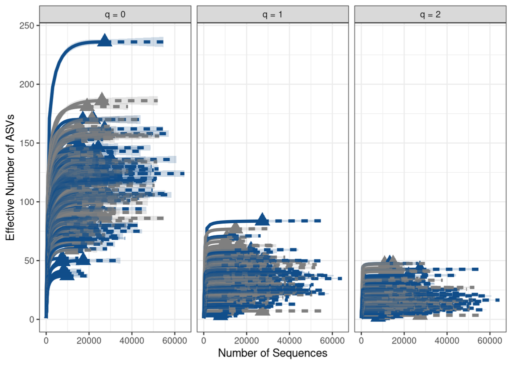

```r
ggiNEXT(iNEXT_data, type = 1, facet.var = "Order.q") +
  scale_color_manual(values = iNEXT_color_df$status_colors) +
  scale_fill_manual(values = iNEXT_color_df$status_colors) +
  scale_shape_manual(values = base::rep(17, nsamples(archaeal_rooted_physeq))) +
  theme_bw() +
  theme(legend.position = "none") +
  labs(y = "Effective Number of ASVs", x = "Number of Sequences")
```

## Manual Rarefaction Curves

```r
str(iNEXT_data)
```

```
## List of 3
##  $ DataInfo:'data.frame':    161 obs. of  14 variables:
##   ..$ Assemblage: chr [1:161] "SRR6443836" "SRR6443839" "SRR6443844" "SRR6443871" ...
##   ..$ n         : num [1:161] 19399 27322 9565 28582 15277 ...
##   ..$ S.obs     : num [1:161] 116 236 124 158 159 161 94 78 103 131 ...
##   ..$ SC        : num [1:161] 1 1 1 1 1 1 1 1 1 1 ...
##   ..$ f1        : num [1:161] 0 0 0 0 0 0 0 0 0 0 ...
##   ..$ f2        : num [1:161] 4 1 2 5 5 6 2 1 7 3 ...
##   ..$ f3        : num [1:161] 3 16 4 5 8 10 3 3 4 12 ...
##   ..$ f4        : num [1:161] 4 3 4 5 3 5 3 5 7 5 ...
##   ..$ f5        : num [1:161] 2 10 3 6 6 6 4 2 2 3 ...
##   ..$ f6        : num [1:161] 3 8 2 5 2 6 1 3 1 0 ...
##   ..$ f7        : num [1:161] 4 5 4 4 5 6 1 4 1 1 ...
##   ..$ f8        : num [1:161] 2 9 4 4 8 1 1 5 3 2 ...
##   ..$ f9        : num [1:161] 1 6 3 4 4 7 4 1 4 3 ...
##   ..$ f10       : num [1:161] 3 4 6 3 4 2 1 1 1 4 ...
##  $ iNextEst:List of 2
##   ..$ size_based    :'data.frame':   19320 obs. of  10 variables:
##   .. ..$ Assemblage: chr [1:19320] "SRR6443836" "SRR6443836" "SRR6443836" "SRR6443836" ...
##   .. ..$ m         : num [1:19320] 1 1078 2156 3233 4311 ...
##   .. ..$ Method    : chr [1:19320] "Rarefaction" "Rarefaction" "Rarefaction" "Rarefaction" ...
##   .. ..$ Order.q   : num [1:19320] 0 0 0 0 0 0 0 0 0 0 ...
##   .. ..$ qD        : num [1:19320] 1 85.4 97.8 103.9 107.5 ...
##   .. ..$ qD.LCL    : num [1:19320] 1 84.2 96.3 102.3 105.8 ...
##   .. ..$ qD.UCL    : num [1:19320] 1 86.7 99.3 105.5 109.2 ...
##   .. ..$ SC        : num [1:19320] 0.0548 0.9819 0.9925 0.9958 0.9973 ...
##   .. ..$ SC.LCL    : num [1:19320] 0.0533 0.9811 0.992 0.9954 0.997 ...
##   .. ..$ SC.UCL    : num [1:19320] 0.0564 0.9826 0.993 0.9962 0.9976 ...
##   ..$ coverage_based:'data.frame':   9177 obs. of  8 variables:
##   .. ..$ Assemblage: chr [1:9177] "SRR6443836" "SRR6443836" "SRR6443836" "SRR6443836" ...
##   .. ..$ SC        : num [1:9177] 0.0548 0.9819 0.9925 0.9958 0.9973 ...
##   .. ..$ m         : num [1:9177] 1 1078 2156 3233 4311 ...
##   .. ..$ Method    : chr [1:9177] "Rarefaction" "Rarefaction" "Rarefaction" "Rarefaction" ...
##   .. ..$ Order.q   : num [1:9177] 0 0 0 0 0 0 0 0 0 0 ...
##   .. ..$ qD        : num [1:9177] 1 85.4 97.8 103.9 107.5 ...
##   .. ..$ qD.LCL    : num [1:9177] 0.981 83.724 95.955 101.912 105.479 ...
##   .. ..$ qD.UCL    : num [1:9177] 1.02 87.12 99.7 105.88 109.58 ...
##  $ AsyEst  :'data.frame':    483 obs. of  7 variables:
##   ..$ Assemblage: chr [1:483] "SRR6443836" "SRR6443836" "SRR6443836" "SRR6443839" ...
##   ..$ Diversity : chr [1:483] "Species richness" "Shannon diversity" "Simpson diversity" "Species richness" ...
##   ..$ Observed  : num [1:483] 116 33.1 18.2 236 83.6 ...
##   ..$ Estimator : num [1:483] 116 33.2 18.2 236 84 ...
##   ..$ s.e.      : num [1:483] 1.987 0.293 0.216 2.033 0.591 ...
##   ..$ LCL       : num [1:483] 116 32.7 17.8 236 82.8 ...
##   ..$ UCL       : num [1:483] 119.9 33.8 18.7 240 85.1 ...
##  - attr(*, "class")= chr "iNEXT"
```

```r
iNEXT_manual_df <-
  iNEXT_data$iNextEst$size_based %>%
  dplyr::rename(names = Assemblage) %>%
  # join with the metadata
  left_join(., metadata_df, by = "names") %>%
  mutate(status = factor(status, levels = c("before",
                                              "during")))

# Inspection
dim(iNEXT_manual_df)
```

```
## [1] 19320    63
```

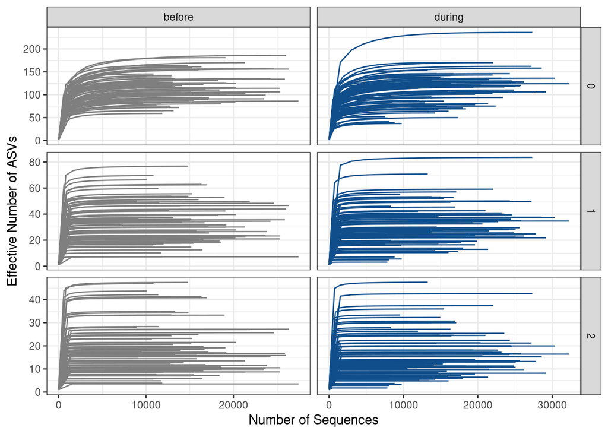

```r
# Manually plot rarefaction curves
iNEXT_manual_df %>%
  # Filter out rows that are calculated with actual sequences (no extrapolated)
  dplyr::filter(Method == "Rarefaction") %>%
  # Now, let's draw the plot!
  ggplot(aes(x = m, y = qD, color = status, group = names)) +
  geom_line() +
  # Facet by status
  facet_grid(Order.q~status, scales = "free") +
  scale_color_manual(values = status_colors) +
  theme_bw() +
  labs(y = "Effective Number of ASVs", x = "Number of Sequences") +
  theme(legend.position = "none")
```

#Interpretation 1: Sequencing depth is likely sufficient, all curves plateau even in richness. There is an outlier sample during the treatment that has an unusually high amount of ASVs, I will need to be in the lookout for that.

*Run Shapiro-Wilk for the scf*

```r
# Test of the data is normal for the continuous value of butyrate
shapiro.test(metadata_df$Butyrate)
```

```
##
##  Shapiro-Wilk normality test
##
## data:  metadata_df$Butyrate
## W = 0.83628, p-value = 7.071e-12
```

```r
# Test of the data is normal for the continuous value of acetate
shapiro.test(metadata_df$acetate)
```

```
##
##  Shapiro-Wilk normality test
##
## data:  metadata_df$acetate
## W = 0.83451, p-value = 3.588e-12
```

```r
# Test of the data is normal for the continuous value of propionate
shapiro.test(metadata_df$propionate)
```

```
##
##  Shapiro-Wilk normality test
##
## data:  metadata_df$propionate
## W = 0.6798, p-value = 2.706e-14
```

```r
# Test of the data is normal for the continuous value of total_scfa
shapiro.test(metadata_df$total_scfa)
```

```
##
##  Shapiro-Wilk normality test
##
## data:  metadata_df$total_scfa
## W = 0.85143, p-value = 4.009e-09
```

Now for the concentration of the 3 scf and total scfa, all of them had p-value<0.05 so none of them are normal, now we can look into richness

```r
### Now what about for richness?
obs_div_df <-
  iNEXT_manual_df %>%
  dplyr::filter(Method == "Observed")

# check it
glimpse(obs_div_df)
```

```
## Rows: 483
## Columns: 63
## $ names                          <chr> "SRR6443836", "SRR6443836", "SRR6443836…
## $ m                              <dbl> 19399, 19399, 19399, 27322, 27322, 2732…
## $ Method                         <chr> "Observed", "Observed", "Observed", "Ob…
## $ Order.q                        <dbl> 0, 1, 2, 0, 1, 2, 0, 1, 2, 0, 1, 2, 0, …
## $ qD                             <dbl> 116.000000, 33.148700, 18.220966, 236.0…
## $ qD.LCL                         <dbl> 114.275814, 32.472264, 17.697990, 233.8…
## $ qD.UCL                         <dbl> 117.724186, 33.825136, 18.743942, 238.1…
## $ SC                             <dbl> 1, 1, 1, 1, 1, 1, 1, 1, 1, 1, 1, 1, 1, …
## $ SC.LCL                         <dbl> 0.9998826, 0.9998826, 0.9998826, 0.9998…
## $ SC.UCL                         <dbl> 1, 1, 1, 1, 1, 1, 1, 1, 1, 1, 1, 1, 1, …
## $ acetate                        <dbl> 9.254869, 9.254869, 9.254869, 21.097292…
## $ Assay.Type                     <chr> "AMPLICON", "AMPLICON", "AMPLICON", "AM…
## $ AvgSpotLen                     <dbl> 500, 500, 500, 500, 500, 500, 500, 500,…
```

[output cut: 50 more lines]

```r
# Pull out unique data from the three fractions of samples
obs_whole_rich_df <-
  obs_div_df %>%
  dplyr::filter(Order.q == 0)

# Test of the data is normal for the continuous value of richness
shapiro.test(obs_whole_rich_df$qD)
```

```
##
##  Shapiro-Wilk normality test
##
## data:  obs_whole_rich_df$qD
## W = 0.98748, p-value = 0.1599
```

###I have paired data (multiple data from the same host before and during) so I am going to run a repeated measures Anova, first prunning the NA values for repeatability. Will run chunks per SCFA type and total_scfa

#Total SCFA RM-Anova

```r
# Prune and average total_scfa
## Prunning breaks the repeated structure of the data, so I will average the different samples per subject into one to approximate the rm ANOVA design.
scfa_summary_df_total_scfa <- metadata_df %>%
  filter(!is.na(total_scfa)) %>%
  group_by(host_subject_id, status) %>%
  summarise(mean_total_scfa = mean(total_scfa), .groups = "drop") %>%
  pivot_wider(names_from = status, values_from = mean_total_scfa) %>%
  drop_na()
# Reshape for Anova
scfa_long_df_total_scfa <- scfa_summary_df_total_scfa %>%
  pivot_longer(cols = c(before, during), names_to = "status", values_to = "total_scfa")
# Repeated measures Anova
scfa_aov_total_scfa <- aov(total_scfa ~ status + Error(host_subject_id), data = scfa_long_df_total_scfa)
summary(scfa_aov_total_scfa)
```

```
##
## Error: host_subject_id
##           Df Sum Sq Mean Sq F value Pr(>F)
## Residuals 21  62863    2994
##
## Error: Within
##           Df Sum Sq Mean Sq F value Pr(>F)
## status     1   1403    1404   0.891  0.356
## Residuals 21  33096    1576
```

```r
# Check rigidity of the model with residuals
resid_vals_total_scfa <- residuals(scfa_aov_total_scfa[["Within"]])
#Check normality of residuals
shapiro.test(resid_vals_total_scfa)
```

```
##
##  Shapiro-Wilk normality test
##
## data:  resid_vals_total_scfa
## W = 0.95418, p-value = 0.3813
```

```r
# differences in before and after
mean_before_total_scfa <- mean(scfa_summary_df_total_scfa$before)
mean_during_total_scfa <- mean(scfa_summary_df_total_scfa$during)
abs_change_total_scfa <- mean_during_total_scfa - mean_before_total_scfa
sd_before_total_scfa <- sd(scfa_summary_df_total_scfa$before)
sd_during_total_scfa <- sd(scfa_summary_df_total_scfa$during)
percent_change_total_scfa <- 100 * abs_change_total_scfa / mean_before_total_scfa

mean_before_total_scfa
```

```
## [1] 69.19191
```

```r
mean_during_total_scfa
```

```
## [1] 80.4875
```

```r
sd_before_total_scfa
```

```
## [1] 34.37317
```

```r
sd_during_total_scfa
```

```
## [1] 58.20631
```

```r
percent_change_total_scfa
```

```
## [1] 16.32502
```

# acetate RM-Anova

```r
# Prune and average acetate
## Prunning breaks the repeated structure of the data, so I will average the different samples per subject into one to approximate the rm ANOVA design.
scfa_summary_df_acetate <- metadata_df %>%
  filter(!is.na(acetate)) %>%
  group_by(host_subject_id, status) %>%
  summarise(mean_acetate = mean(acetate), .groups = "drop") %>%
  pivot_wider(names_from = status, values_from = mean_acetate) %>%
  drop_na()
# Reshape for Anova
scfa_long_df_acetate <- scfa_summary_df_acetate %>%
  pivot_longer(cols = c(before, during), names_to = "status", values_to = "acetate")
# Repeated measures Anova
scfa_aov_acetate <- aov(acetate ~ status + Error(host_subject_id), data = scfa_long_df_acetate)
summary(scfa_aov_acetate)
```

```
##
## Error: host_subject_id
##           Df Sum Sq Mean Sq F value Pr(>F)
## Residuals 22  17644     802
##
## Error: Within
##           Df Sum Sq Mean Sq F value Pr(>F)
## status     1     84   84.29   0.348  0.561
## Residuals 22   5321  241.88
```

```r
# Check rigidity of the model with residuals
resid_vals_acetate <- residuals(scfa_aov_acetate[["Within"]])
#Check normality of residuals
shapiro.test(resid_vals_acetate)
```

```
##
##  Shapiro-Wilk normality test
##
## data:  resid_vals_acetate
## W = 0.93687, p-value = 0.1539
```

```r
# differences in before and after
mean_before_acetate <- mean(scfa_summary_df_acetate$before)
mean_during_acetate <- mean(scfa_summary_df_acetate$during)
abs_change_acetate <- mean_during_acetate - mean_before_acetate
sd_before_acetate <- sd(scfa_summary_df_acetate$before)
sd_during_acetate <- sd(scfa_summary_df_acetate$during)
percent_change_acetate <- 100 * abs_change_acetate / mean_before_acetate

mean_before_acetate
```

```
## [1] 40.21256
```

```r
mean_during_acetate
```

```
## [1] 42.9199
```

```r
sd_before_acetate
```

```
## [1] 20.31895
```

```r
sd_during_acetate
```

```
## [1] 25.11975
```

```r
percent_change_acetate
```

```
## [1] 6.732593
```

# Butyrate RM-Anova

```r
# Prune and average Butyrate
## Prunning breaks the repeated structure of the data, so I will average the different samples per subject into one to approximate the rm ANOVA design.
scfa_summary_df_Butyrate <- metadata_df %>%
  filter(!is.na(Butyrate)) %>%
  group_by(host_subject_id, status) %>%
  summarise(mean_Butyrate = mean(Butyrate), .groups = "drop") %>%
  pivot_wider(names_from = status, values_from = mean_Butyrate) %>%
  drop_na()
# Reshape for Anova
scfa_long_df_Butyrate <- scfa_summary_df_Butyrate %>%
  pivot_longer(cols = c(before, during), names_to = "status", values_to = "Butyrate")
# Repeated measures Anova
scfa_aov_Butyrate <- aov(Butyrate ~ status + Error(host_subject_id), data = scfa_long_df_Butyrate)
summary(scfa_aov_Butyrate)
```

```
##
## Error: host_subject_id
##           Df Sum Sq Mean Sq F value Pr(>F)
## Residuals 22   1167   53.03
##
## Error: Within
##           Df Sum Sq Mean Sq F value Pr(>F)
## status     1    5.4   5.416   0.353  0.559
## Residuals 22  337.6  15.347
```

```r
# Check rigidity of the model with residuals
resid_vals_Butyrate <- residuals(scfa_aov_Butyrate[["Within"]])
#Check normality of residuals
shapiro.test(resid_vals_Butyrate)
```

```
##
##  Shapiro-Wilk normality test
##
## data:  resid_vals_Butyrate
## W = 0.98015, p-value = 0.9087
```

```r
# differences in before and after
mean_before_Butyrate <- mean(scfa_summary_df_Butyrate$before)
mean_during_Butyrate <- mean(scfa_summary_df_Butyrate$during)
abs_change_Butyrate <- mean_during_Butyrate - mean_before_Butyrate
sd_before_Butyrate <- sd(scfa_summary_df_Butyrate$before)
sd_during_Butyrate <- sd(scfa_summary_df_Butyrate$during)
percent_change_Butyrate <- 100 * abs_change_Butyrate / mean_before_Butyrate

mean_before_Butyrate
```

```
## [1] 10.0786
```

```r
mean_during_Butyrate
```

```
## [1] 10.76483
```

```r
sd_before_Butyrate
```

```
## [1] 5.284116
```

```r
sd_during_Butyrate
```

```
## [1] 6.360645
```

```r
percent_change_Butyrate
```

```
## [1] 6.808832
```

#Propionate RM-Anova

```r
# Prune and average propionate
## Prunning breaks the repeated structure of the data, so I will average the different samples per subject into one to approximate the rm ANOVA design.
scfa_summary_df_propionate <- metadata_df %>%
  filter(!is.na(propionate)) %>%
  group_by(host_subject_id, status) %>%
  summarise(mean_propionate = mean(propionate), .groups = "drop") %>%
  pivot_wider(names_from = status, values_from = mean_propionate) %>%
  drop_na()
# Reshape for Anova
scfa_long_df_propionate <- scfa_summary_df_propionate %>%
  pivot_longer(cols = c(before, during), names_to = "status", values_to = "propionate")
# Repeated measures Anova
scfa_aov_propionate <- aov(propionate ~ status + Error(host_subject_id), data = scfa_long_df_propionate)
summary(scfa_aov_propionate)
```

```
##
## Error: host_subject_id
##           Df Sum Sq Mean Sq F value Pr(>F)
## Residuals 21   6114   291.1
##
## Error: Within
##           Df Sum Sq Mean Sq F value Pr(>F)
## status     1    127   126.6   0.446  0.512
## Residuals 21   5964   284.0
```

```r
# Check rigidity of the model with residuals
resid_vals_propionate <- residuals(scfa_aov_propionate[["Within"]])
#Check normality of residuals
shapiro.test(resid_vals_propionate)
```

```
##
##  Shapiro-Wilk normality test
##
## data:  resid_vals_propionate
## W = 0.95694, p-value = 0.4299
```

```r
# differences in before and after
mean_before_propionate <- mean(scfa_summary_df_propionate$before)
mean_during_propionate <- mean(scfa_summary_df_propionate$during)
abs_change_propionate <- mean_during_propionate - mean_before_propionate
sd_before_propionate <- sd(scfa_summary_df_propionate$before)
sd_during_propionate <- sd(scfa_summary_df_propionate$during)
percent_change_propionate <- 100 * abs_change_propionate / mean_before_propionate

mean_before_propionate
```

```
## [1] 17.39253
```

```r
mean_during_propionate
```

```
## [1] 20.78483
```

```r
sd_before_propionate
```

```
## [1] 12.89585
```

```r
sd_during_propionate
```

```
## [1] 20.21955
```

```r
percent_change_propionate
```

```
## [1] 19.50437
```

[output not shown]